# Assigment 1 - Predictive Modeling

### Final model

The model is built using all the variables selected through the improved predictor selection process, with the addition of two interaction terms to capture potential combined effects between variables. The included interactions are: `INVOICING_TOTAL_TAXES` * `NUM_MAIN_POSTPAID_LINES`, which examines how the relationship between invoicing and the probability of purchase is influenced by the number of postpaid lines as seen in the 2º model, and `ZONE_FIXED_PENETRATION` * `MOBILE_CALLS`, which explores how the impact of mobile calls varies depending on the fixed-line penetration in the customer’s region.

| Observations | 14999 |
| --- | --- |
| Dependent variable | TARGET |
| Type | Generalized linear model |
| Family | binomial |
| Link | logit |

| χ²(17) | 1148.534 |
| --- | --- |
| Pseudo-R² (Cragg-Uhler) | 0.104 |
| Pseudo-R² (McFadden) | 0.062 |
| AIC | 17483.674 |
| BIC | 17620.758 |

|  | Est. | S.E. | z val. | p |
| --- | --- | --- | --- | --- |
| (Intercept) | -2.044 | 0.136 | -15.006 | 0.000 |
| INVOICING_TOTAL_TAXES | 0.012 | 0.002 | 7.634 | 0.000 |
| INVOICING_QUOTA | 0.015 | 0.003 | 5.538 | 0.000 |
| SECONDS_CALL_OWN_NETWORK | 0.000 | 0.000 | 3.247 | 0.001 |
| MONTHLY_MB | 0.000 | 0.000 | 2.233 | 0.026 |
| AGE | -0.017 | 0.001 | -12.265 | 0.000 |
| NUM_CALLS_OWN_NETWORK | 0.001 | 0.000 | 5.027 | 0.000 |
| NUM_MAIN_POSTPAID_LINES | 0.641 | 0.084 | 7.645 | 0.000 |
| NUM_DAYS_CONVERGENT | 0.000 | 0.000 | 2.597 | 0.009 |
| NUM_CANCELLATIONS | -0.095 | 0.021 | -4.517 | 0.000 |
| MOBILE_CALLS | 0.082 | 0.034 | 2.395 | 0.017 |
| NUM_DAYS_ACTIVE | -0.000 | 0.000 | -2.480 | 0.013 |
| NUM_BUNDLE_DAYS | 0.000 | 0.000 | 3.245 | 0.001 |
| TOTAL_BRAND_SERVICES | -0.094 | 0.044 | -2.138 | 0.033 |
| TOTAL_POSTPAID_SERVICES | 0.115 | 0.024 | 4.855 | 0.000 |
| ZONE_FIXED_PENETRATION | 2.125 | 0.261 | 8.142 | 0.000 |
| INVOICING_TOTAL_TAXES:NUM_MAIN_POSTPAID_LINES | -0.007 | 0.001 | -7.523 | 0.000 |
| MOBILE_CALLS:ZONE_FIXED_PENETRATION | -0.228 | 0.097 | -2.356 | 0.018 |

Standard errors: MLE

The model is statistically significant, as indicated by the Chi-Squared test, and has an AIC of 17483.67. which is the lowest of all. Key predictors include `ZONE_FIXED_PENETRATION`, which has the highest positive coefficient (2.13), reaffirming its strong influence on the probability of purchase, and `NUM_MAIN_POSTPAID_LINES`, which is also a significant driver. Among the interaction terms, `INVOICING_TOTAL_TAXES:NUM_MAIN_POSTPAID_LINES` shows a negative coefficient, indicating diminishing returns in the combined effect of invoicing and the number of postpaid lines. Similarly, `MOBILE_CALLS:ZONE_FIXED_PENETRATION` exhibits a negative effect, suggesting that the impact of mobile calls diminishes in areas with higher fixed-line penetration.

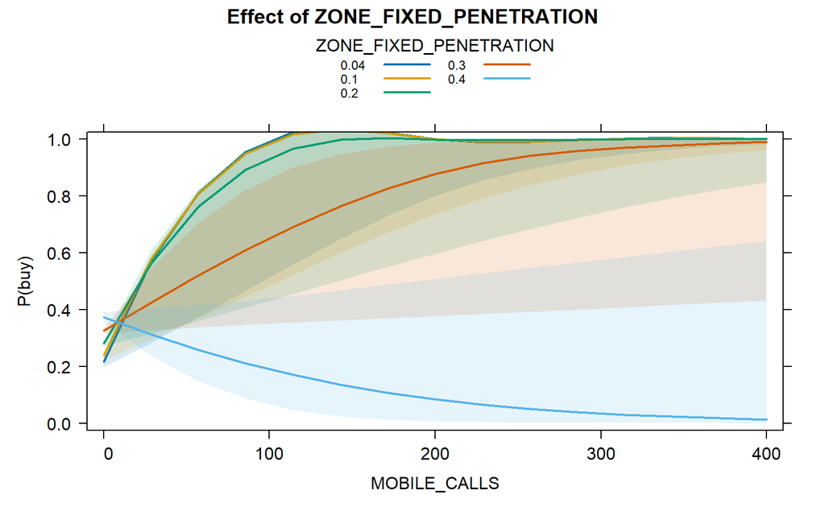

```r
plot(effect("MOBILE_CALLS:ZONE_FIXED_PENETRATION", glm_best_select),
     ci.style="band",
     rescale.axis=FALSE,
     multiline=TRUE,
     ylab="P(buy)",
     rug=FALSE,
     main="Effect of ZONE_FIXED_PENETRATION")
```

Due to the large uncertainty represented by the wide confidence bands in this graph, the interpretation will focus on distinguishing between `ZONE_FIXED_PENETRATION` = 0.4 and the other levels, which is the clearest pattern observable.

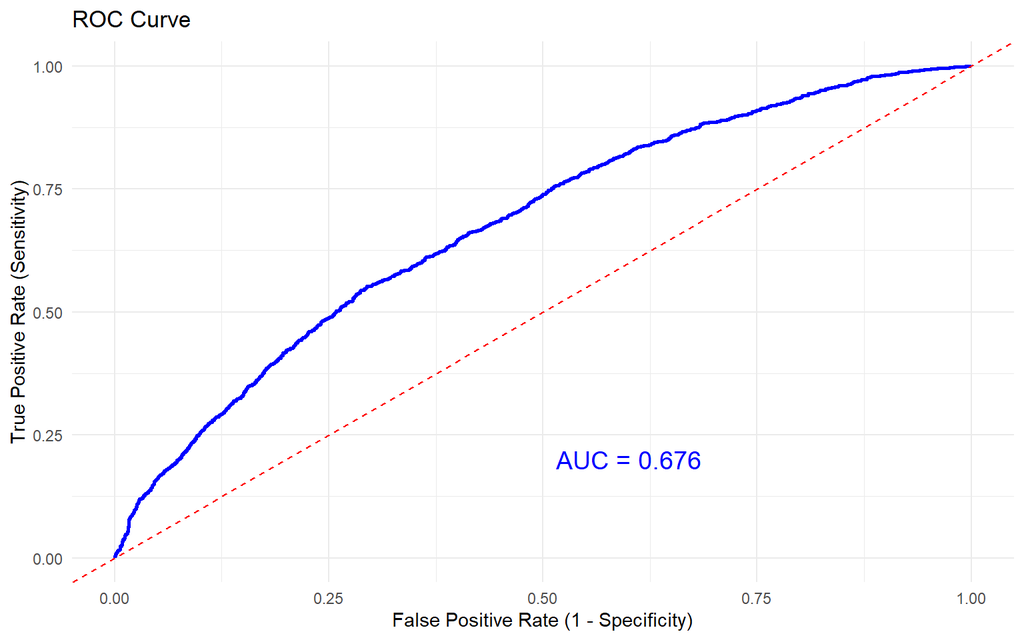

In this final model the **AUC is 0.676**, the highest one.

Evaluation metrics

| Metric | Value |
| --- | --- |
| Accuracy | 0.7036593 |
| 95% CI (Lower) | 0.6907870 |
| 95% CI (Upper) | 0.7162934 |
| Sensitivity | 0.9428157 |
| Specificity | 0.1741645 |
| Pos Pred Value | 0.7165233 |
| Neg Pred Value | 0.5790598 |
| Balanced Accuracy | 0.5584901 |

The final model demonstrates a **slight improvement**, with accuracy reaching **0.704** and **balanced accuracy** increasing to **0.558**, reflecting better performance in handling class imbalance. Sensitivity remains strong at 0.943, effectively detecting positive cases, while specificity has improved further to 0.174, though it is still relatively low.

### Benchmark Model

We will use a **benchmark model** to compare the performance of our more complex models. The benchmark model consists of **only** the **intercept**, meaning it does not include any predictors and assumes that the probability of the target event is constant across all observations. This provides a baseline representation of the data and allows us to measure how much explanatory power and predictive accuracy are gained by incorporating predictors and interactions in subsequent models.

```r
benchmark_model <- glm(TARGET ~ 1, data = mobile_train_cleaned, family = binomial)
summ(benchmark_model, digits = 3)
```

| Observations | 14999 |
| --- | --- |
| Dependent variable | TARGET |
| Type | Generalized linear model |
| Family | binomial |
| Link | logit |

| χ²(0) | -0.000 |
| --- | --- |
| Pseudo-R² (Cragg-Uhler) | 0.000 |
| Pseudo-R² (McFadden) | 0.000 |
| AIC | 18598.208 |
| BIC | 18605.824 |

|  | Est. | S.E. | z val. | p |
| --- | --- | --- | --- | --- |
| (Intercept) | -0.795 | 0.018 | -45.091 | 0.000 |

Standard errors: MLE

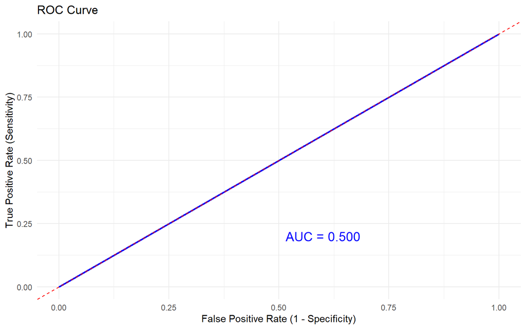

This benchmark model consists solely of the intercept, which represents the overall log-odds of the target event (TARGET) without any predictors. The **AIC of 18598.208** and the lack of variability explained by the model $(Pseudo R^2 = 0)$indicate that it provides no predictive power beyond the baseline probability of the event. The ROC curve confirms this, with an **AUC of 0.500*+, which is equivalent to random guessing. All the models done in this project are better than this model.

## Comparision between models and conclusions

To provide a baseline for comparison, a benchmark model was created using only the intercept, with no predictors or interactions. This establishes a minimal baseline against which the predictive power and improvements of all subsequent models can be measured.

All models significantly **outperformed the benchmark model**, as evidenced by higher AUC, lower AIC, and improved metrics like balanced accuracy. This demonstrates the added value of incorporating predictors and interactions in explaining and predicting customer behaviour.

Each successive model showed incremental improvements in metrics such as AUC, balanced accuracy, and specificity. The final model exhibited the best performance, with the lowest AIC and the highest AUC, balanced accuracy, and specificity.

Across all models, `ZONE_FIXED_PENETRATION` emerged as the most influential predictor, highlighting the importance of regional fixed-line penetration. Other key factors included `NUM_MAIN_POSTPAID_LINES` and `INVOICING_QUOTA`, demonstrating their relevance in explaining customer purchasing behaviour.

Model Comparison Table: Key Metrics

Models

Metric

Benchmark Model

Model 1

Model 2

Model 3

Final Model

AUC

0.500

0.652

0.654

0.674

0.676

Accuracy

0.691

0.694

0.703

0.704

Balanced Accuracy

0.521

0.533

0.555

0.558

Sensitivity

0.971

0.960

0.947

0.943

Specificity

0.072

0.105

0.163

0.174

AIC

18598.208

17978.919

17861.529

17554.890

17483.670

The **final model** incorporation of interaction terms enhanced its explanatory power, providing deeper insights into complex relationships. With an **AUC of 0.676**, it demonstrated the best ability to distinguish between classes, making it the most reliable model developed in this project.